# Exploratory Analysis

The number of movies they cast for must larger then 5 movies

```python
cast = parseWithMoneyAndCount(data, 'Cast')
cast.sort_values(by='Count', ascending=False, inplace=True)
cast10Movies = cast[cast['Count'] > 5]
cast10Movies.sort_values(by='Mean', ascending=False, inplace=True)
cast10Movies.reset_index(drop=True, inplace=True)
cast10Movies
```

|  | Cast | Total | Count | Mean | Median |
| --- | --- | --- | --- | --- | --- |
| 0 | Rupert Grint | 7786412658 | 8 | 9.733016e+08 | 9.383132e+08 |
| 1 | Lupita Nyong'o | 7278884954 | 8 | 9.098606e+08 | 1.020352e+09 |
| 2 | Evangeline Lilly | 6209206084 | 7 | 8.870294e+08 | 6.226741e+08 |
| 3 | Chadwick Boseman | 7668338102 | 9 | 8.520376e+08 | 1.506809e+08 |
| 4 | Karen Gillan | 8474182724 | 10 | 8.474183e+08 | 7.867049e+08 |
| ... | ... | ... | ... | ... | ... |
| 4569 | Deborah Kerr | 21481898 | 6 | 3.580316e+06 | 3.325950e+04 |
| 4570 | Rita Taggart | 19991204 | 6 | 3.331867e+06 | 2.243077e+06 |
| 4571 | Tony Curtis | 26234046 | 8 | 3.279256e+06 | 1.610252e+06 |
| 4572 | Dick Cavett | 30866179 | 10 | 3.086618e+06 | 1.324484e+06 |
| 4573 | Arsinée Khanjian | 15305635 | 6 | 2.550939e+06 | 3.003460e+06 |

4574 rows × 5 columns

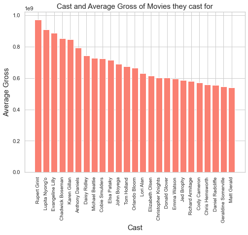

```python
plt.figure(figsize=(8, 6))
data3 = cast10Movies.sort_values(by='Mean', ascending=False)[0:25]
plt.bar(data=data3, x='Cast', height='Mean', color="salmon")
plt.xticks(rotation=90, fontsize=10)
plt.title("Cast and Average Gross of Movies they cast for", fontsize=15)
plt.xlabel("Cast", fontsize=15)
plt.ylabel("Average Gross", fontsize=15)
plt.show()
```

We call them leader cast. And now move on to develop rank

```python
cast10Movies.sort_values(by='Mean', ascending=True, inplace=True)
castRank = dict()
for i, row in enumerate(cast10Movies['Cast']):
    castRank[row] = i + 1
castRank
```

```
{'Arsinée Khanjian': 1,
 'Dick Cavett': 2,
 'Tony Curtis': 3,
 'Rita Taggart': 4,
 'Deborah Kerr': 5,
 'John Lennon': 6,
 'Victoria Abril': 7,
 'Jill Schoelen': 8,
 'Alison Steadman': 9,
 'Jacques Mathou': 10,
 'Lior Ashkenazi': 11,
 'Ramon Bieri': 12,
 'Mink Stole': 13,
 'Traci Lind': 14,
 'Emilio Fernández': 15,
 'Jim Metzler': 16,
 'Kathryn Grody': 17,
 'Cheryl Ladd': 18,
 'Patrick Huard': 19,
 'John Cullum': 20,
 'Ricki Lake': 21,
 'Jack Rader': 22,
 'Blu Mankuma': 23,
 'Peter Eyre': 24,
 'Gore Vidal': 25,
 'Don McKellar': 26,
 'Suniel Shetty': 27,
 'Matt Keeslar': 28,
 'Anne-Marie Johnson': 29,
 'Humphrey Bogart': 30,
 'Luke Askew': 31,
 'Marcello Mastroianni': 32,
 'Richard Widmark': 33,
 'John Savident': 34,
 'Vrajesh Hirjee': 35,
 'Millie Perkins': 36,
 'Tim Barlow': 37,
 'Anna Massey': 38,
 'Jodie Markell': 39,
 'Amy Locane': 40,
```

[output cut: 946 more lines]

```
 'Duncan Fraser': 987,
 'Matt Clark': 988,
 "Beverly D'Angelo": 989,
 'Bud Cort': 990,
 'Macy Gray': 991,
 'Gwen McGee': 992,
 'Martha Gehman': 993,
 'Roxanne Hart': 994,
 'Erich Anderson': 995,
 'Felicity Huffman': 996,
 'Brendan Sexton III': 997,
 'Natasha Richardson': 998,
 'Wayne Grace': 999,
 'Tom Towles': 1000,
 ...}
```

Apply to data to get CastsRank. Here we total the rank value

```python
def getCastsTeamRank(casts):
    total = 0
    for cast in casts:
        if cast not in castRank.keys():
            total += random.randint(1, 200)
            continue
        total += castRank[cast]
    return total
```

```python
data2 = data.copy()
data2['CastsRank'] = data2['Cast'].apply(getCastsTeamRank)
data2['CastsRank'].value_counts()
```

```
2055     6
0        5
17485    4
1806     4
1953     4
        ..
27199    1
4658     1
27183    1
33941    1
31443    1
Name: CastsRank, Length: 7779, dtype: int64
```

```
Pearsons correlation between CastsRank and Gross: 0.526
```

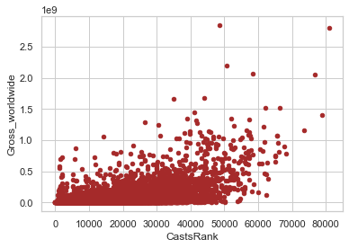

```python
corr = pearsonr(data2['CastsRank'], data2['Gross_worldwide'])[0]
print('Pearsons correlation between CastsRank and Gross: %.3f' % corr)
data2.plot.scatter(x='CastsRank', y='Gross_worldwide', color='brown')
```

```python
final['CastsRank'] = data2['CastsRank']
```

How about we take the rank means?

```python
def getCastsTeamRank(casts):
    length = len(casts)
    if length == 0:
        length = 1
    total = 0
    for cast in casts:
        if cast in castRank.keys():
            total += castRank[cast]
    return total / length
```

```
Pearsons correlation between CastsRank and Gross: 0.513
```

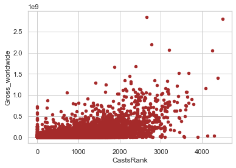

```python
data2 = data.copy()
data2['CastsRank'] = data2['Cast'].apply(getCastsTeamRank)
data2['CastsRank'].value_counts()
corr = pearsonr(data2['CastsRank'], data2['Gross_worldwide'])[0]
print('Pearsons correlation between CastsRank and Gross: %.3f' % corr)
data2.plot.scatter(x='CastsRank', y='Gross_worldwide', color='brown')
```

Both are approximately identical correlation value of **0.51**

Now we will extract more feature That is:

**NumLeadActors**

```python
cast10Movies.sort_values(by='Mean', ascending=False, inplace=True)
top100Cast = list(cast10Movies['Cast'][0:100])


def getNumLeadActors(casts):
    total = 0
    for cast in casts:
        if cast in top100Cast:
            total += 1
    return total


data2 = data.copy()
data2['NumLeadActors'] = data2['Cast'].apply(getNumLeadActors)
data2['NumLeadActors'].value_counts()
```

```
0     7988
1      574
2      103
3       34
4       22
5       15
7        5
9        4
8        3
6        2
11       2
Name: NumLeadActors, dtype: int64
```

```
Pearsons correlation between NumLeadActors and Gross: 0.593
```

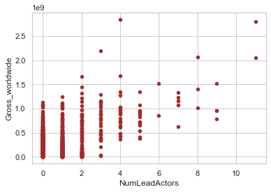

```python
corr = pearsonr(data2['NumLeadActors'], data2['Gross_worldwide'])[0]
print('Pearsons correlation between NumLeadActors and Gross: %.3f' % corr)
data2.plot.scatter(x='NumLeadActors', y='Gross_worldwide', color='brown')
```

```python
final['NumLeadActors'] = data2['NumLeadActors']
```

```
Pearsons correlation between HasTop50Actors and Gross: 0.364
```

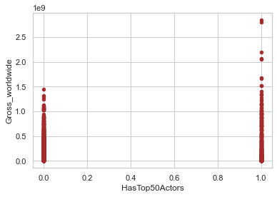

```python
cast10Movies.sort_values(by='Mean', ascending=False, inplace=True)
top50Cast = list(cast10Movies['Cast'][0:50])


def getHasTop30Actors(casts):
    for cast in casts:
        if cast in top50Cast:
            return 1
    return 0


data2 = data.copy()
data2['HasTop50Actors'] = data2['Cast'].apply(getHasTop30Actors)
corr = pearsonr(data2['HasTop50Actors'], data2['Gross_worldwide'])[0]
print('Pearsons correlation between HasTop50Actors and Gross: %.3f' % corr)
data2.plot.scatter(x='HasTop50Actors', y='Gross_worldwide', color='brown')
```

```python
final['HasTop50Actors'] = data2['HasTop50Actors']
```

## Crew analysis

Hypothesis: Does revenue depend on number of crews appear on movie's imdb website?

```
Pearsons correlation between NumCrews and Gross: 0.190
```

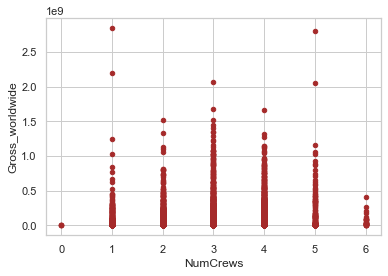

```python
data2 = data.copy()
data2['NumCrews'] = data2['Crew'].apply(lambda x: len(x))
corr = pearsonr(data2['NumCrews'], data2['Gross_worldwide'])[0]
print('Pearsons correlation between NumCrews and Gross: %.3f' % corr)
data2.plot.scatter(x='NumCrews', y='Gross_worldwide', color='brown')
```

```python
final['NumCrews'] = data2['NumCrews']
```

```python
crew = parseWithMoneyAndCount(data, 'Crew')
crew.sort_values(by='Count', ascending=False)
```

|  | Crew | Total | Count | Mean | Median |
| --- | --- | --- | --- | --- | --- |
| 10649 | Woody Allen | 1192064607 | 43 | 2.772243e+07 | 14792779.0 |
| 1879 | Clint Eastwood | 3458362840 | 38 | 9.100955e+07 | 53572298.0 |
| 9561 | Stephen King | 1891234174 | 36 | 5.253428e+07 | 22759009.5 |
| 9715 | Steven Spielberg | 10743871515 | 34 | 3.159962e+08 | 288074136.5 |
| 5181 | John Hughes | 2930471621 | 33 | 8.880217e+07 | 49944325.0 |
| ... | ... | ... | ... | ... | ... |
| 4407 | James Leo Herlihy | 44801177 | 1 | 4.480118e+07 | 44801177.0 |
| 4406 | James Lee Burke | 5009305 | 1 | 5.009305e+06 | 5009305.0 |
| 4405 | James Lee Barrett | 126737428 | 1 | 1.267374e+08 | 126737428.0 |
| 4404 | James Lasdun | 2048740 | 1 | 2.048740e+06 | 2048740.0 |
| 10777 | Óskar Jónasson | 96262212 | 1 | 9.626221e+07 | 96262212.0 |

10778 rows × 5 columns

Number of movies each crew participate in

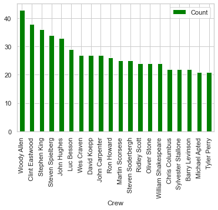

```python
crew.sort_values(by='Count', ascending=False)[0:20].plot.bar(x='Crew', y='Count', color='green')
```

```python
crew.sort_values(by='Mean', ascending=False)[0:20]
```

|  | Crew | Total | Count | Mean | Median |
| --- | --- | --- | --- | --- | --- |
| 639 | Anthony Russo | 6844248984 | 5 | 1.368850e+09 | 1.153337e+09 |
| 5007 | Joe Russo | 6844248984 | 5 | 1.368850e+09 | 1.153337e+09 |
| 5004 | Joe Robert Cole | 1347597973 | 1 | 1.347598e+09 | 1.347598e+09 |
| 9486 | Stan Lee | 13024534758 | 12 | 1.085378e+09 | 9.784765e+08 |
| 5526 | Josh Cooley | 1073394593 | 1 | 1.073395e+09 | 1.073395e+09 |
| 5198 | John Knoll | 1056057720 | 1 | 1.056058e+09 | 1.056058e+09 |
| 3046 | Eric Guillon | 1034800131 | 1 | 1.034800e+09 | 1.034800e+09 |
| 557 | Angus MacLane | 1028570942 | 1 | 1.028571e+09 | 1.028571e+09 |
| 10351 | Victoria Strouse | 1028570942 | 1 | 1.028571e+09 | 1.028571e+09 |
| 5389 | Jon Watts | 2012094920 | 2 | 1.006047e+09 | 1.006047e+09 |
| 4760 | Jennifer Lee | 2864210897 | 3 | 9.547370e+08 | 1.281508e+09 |
| 8205 | Pierre Coffin | 3708124783 | 4 | 9.270312e+08 | 1.002783e+09 |
| 4229 | J.K. Rowling | 9255312560 | 10 | 9.255313e+08 | 9.155662e+08 |
| 6324 | Lori Forte | 877244782 | 1 | 8.772448e+08 | 8.772448e+08 |
| 10688 | Yi Liu | 870325439 | 1 | 8.703254e+08 | 8.703254e+08 |
| 8264 | Qun Dong | 870325439 | 1 | 8.703254e+08 | 8.703254e+08 |
| 4935 | Jing Wu | 870325439 | 1 | 8.703254e+08 | 8.703254e+08 |
| 4475 | Jan Duursema | 868390560 | 1 | 8.683906e+08 | 8.683906e+08 |
| 9571 | Stephen McFeely | 8655378624 | 10 | 8.655379e+08 | 5.322244e+08 |
| 526 | Andy Lanning | 863756051 | 1 | 8.637561e+08 | 8.637561e+08 |

There are lots writers and directors who participate only in few movies

```python
releases4crew = crew[crew['Count'] > 4]
releases4crew.sort_values(by='Mean', ascending=False)[0:20]
```

|  | Crew | Total | Count | Mean | Median |
| --- | --- | --- | --- | --- | --- |
| 639 | Anthony Russo | 6844248984 | 5 | 1.368850e+09 | 1.153337e+09 |
| 5007 | Joe Russo | 6844248984 | 5 | 1.368850e+09 | 1.153337e+09 |
| 9486 | Stan Lee | 13024534758 | 12 | 1.085378e+09 | 9.784765e+08 |
| 4229 | J.K. Rowling | 9255312560 | 10 | 9.255313e+08 | 9.155662e+08 |
| 9571 | Stephen McFeely | 8655378624 | 10 | 8.655379e+08 | 5.322244e+08 |
| 2494 | David Yates | 6021591899 | 7 | 8.602274e+08 | 9.344541e+08 |
| 1779 | Christopher Markus | 9400391739 | 11 | 8.545811e+08 | 6.447831e+08 |
| 6172 | Lee Unkrich | 3892224463 | 5 | 7.784449e+08 | 8.078179e+08 |
| 8173 | Philippa Boyens | 6663807561 | 9 | 7.404231e+08 | 9.474951e+08 |
| 489 | Andrew Stanton | 5672435426 | 8 | 7.090544e+08 | 7.308323e+08 |
| 6992 | Michael Arndt | 3359222246 | 5 | 6.718444e+08 | 2.861686e+08 |
| 1237 | Brian Lynch | 3203896208 | 5 | 6.407792e+08 | 5.549875e+08 |
| 9637 | Steve Kloves | 7669781515 | 12 | 6.391485e+08 | 8.384820e+08 |
| 1281 | Bruce Geller | 3173171913 | 5 | 6.346344e+08 | 6.827166e+08 |
| 1691 | Chris Renaud | 3168230230 | 5 | 6.336460e+08 | 5.431140e+08 |
| 4687 | Jeff Nathanson | 4425072143 | 7 | 6.321532e+08 | 3.521143e+08 |
| 8784 | Robert Wade | 4923637935 | 8 | 6.154547e+08 | 6.030417e+08 |
| 1680 | Chris McKenna | 3059989349 | 5 | 6.119979e+08 | 6.226741e+08 |
| 3256 | Fran Walsh | 6696215912 | 11 | 6.087469e+08 | 8.976901e+08 |
| 2593 | Derek Connolly | 3020187001 | 5 | 6.040374e+08 | 5.666528e+08 |

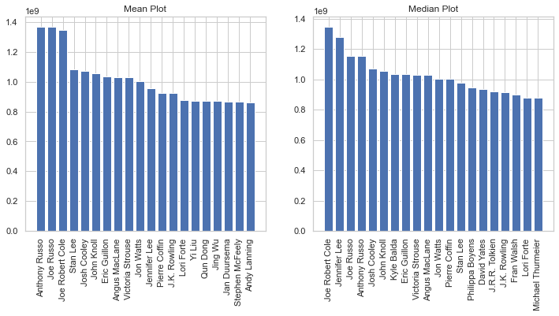

```python
fig = plt.figure(figsize=(12, 5))
plt.subplot(1, 2, 1)
plt.bar(data=crew.sort_values(by='Mean', ascending=False)[0:20], x='Crew', height='Mean')
plt.xticks(rotation=90)
plt.title("Mean Plot")
plt.subplot(1, 2, 2)
plt.bar(data=crew.sort_values(by='Median', ascending=False)[0:20], x='Crew', height='Median')
# crew.sort_values(by='Mean',ascending=False)[0:20].plot.bar(x='Crew',y='Mean')
plt.xticks(rotation=90)
plt.title("Median Plot")
plt.show()
```

The top seems not change very much

Now we will develop rank of crew

```python
crewRank = dict()
releases4crew = releases4crew.sort_values(by='Mean').reset_index(drop=True)
for i, row in enumerate(releases4crew['Crew']):
    crewRank[row] = i + 1
crewRank
```

```
{'Federico Fellini': 1,
 'André Téchiné': 2,
 'Ingmar Bergman': 3,
 'Todd Solondz': 4,
 'Errol Morris': 5,
 'Warren Miller': 6,
 'Bill Forsyth': 7,
 'Krzysztof Kieslowski': 8,
 'Krzysztof Piesiewicz': 9,
 'Sally Potter': 10,
 'Louis Malle': 11,
 'Mark Monroe': 12,
 'Henry James': 13,
 'Alan Rudolph': 14,
 'Zalman King': 15,
 'Hanif Kureishi': 16,
 'Atom Egoyan': 17,
 'Naomi Foner': 18,
 'François Truffaut': 19,
 'Bille August': 20,
 'Werner Herzog': 21,
 'Desmond Nakano': 22,
 'Alfred Hitchcock': 23,
 'Agnieszka Holland': 24,
 'Sam Peckinpah': 25,
 'Olivier Assayas': 26,
 'Harold Pinter': 27,
 'Patrice Leconte': 28,
 'Laura Jones': 29,
 'Allan Scott': 30,
 'Billy Wilder': 31,
 'Don Coscarelli': 32,
 'Whit Stillman': 33,
 'Sergio Donati': 34,
 'David Zelag Goodman': 35,
 'James R. Silke': 36,
 'Robin Bhatt': 37,
 'Frank Cottrell Boyce': 38,
 'Menahem Golan': 39,
 'Michael Winterbottom': 40,
```

[output cut: 946 more lines]

```
 'John August': 987,
 'Kelly Asbury': 988,
 'Michael McCullers': 989,
 'Phil Lord': 990,
 'Scott Silver': 991,
 'David S. Goyer': 992,
 'Chris Weitz': 993,
 'Peter S. Seaman': 994,
 'Jake Kasdan': 995,
 'Guy Ritchie': 996,
 'Michael Green': 997,
 'Marc Webb': 998,
 'Etan Cohen': 999,
 'Steven Spielberg': 1000,
 ...}
```

```python
len(crewRank)
```

```
1091
```

Now we will rank the movies based on crew team rank

```python
import random


def getCrewsTeamRank(crews):
    total = 0
    for crew in crews:
        if crew not in crewRank.keys():
            total += random.randint(1, 100)
            continue
        total += crewRank[crew]
    return total


data2 = data.copy()
data2['crewsTeamRank'] = data2['Crew'].apply(getCrewsTeamRank)
data2['crewsTeamRank'].value_counts()
```

```
260     41
74      30
132     30
73      29
102     29
        ..
2315     1
1239     1
637      1
1400     1
2606     1
Name: crewsTeamRank, Length: 2110, dtype: int64
```

```
Pearsons correlation between crewsTeamRank and Gross: 0.550
```

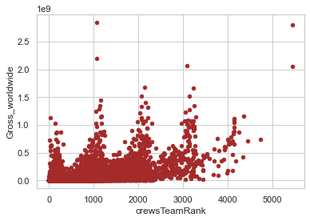

```python
corr = pearsonr(data2['crewsTeamRank'], data2['Gross_worldwide'])[0]
print('Pearsons correlation between crewsTeamRank and Gross: %.3f' % corr)
data2.plot.scatter(x='crewsTeamRank', y='Gross_worldwide', color='brown')
```

```python
final['crewsTeamRank'] = data2['crewsTeamRank']
```

Result correlation:

- By mean total rank: 0.551
- By mean mean rank: 0.516
- By median total rank : 0.535
- By median mean rank : 0.470

Now consider number of crew in top 150 for each movie

```python
releases4crew.sort_values(by='Mean', ascending=False, inplace=True)
top150Crew = list(releases4crew['Crew'][0:150])


def getNumTopCrew(crews):
    total = 0
    for crew in crews:
        if crew in top150Crew:
            total += 1
    return total


data2 = data.copy()
data2['NumTopCrew'] = data2['Crew'].apply(getNumTopCrew)
data2['NumTopCrew'].value_counts()
```

```
0    7911
1     555
2     187
3      76
4      21
5       2
Name: NumTopCrew, dtype: int64
```

```
Pearsons correlation between NumTopCrew and Gross: 0.621
```

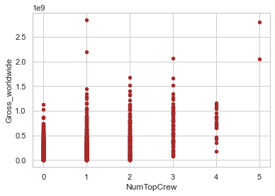

```python
corr = pearsonr(data2['NumTopCrew'], data2['Gross_worldwide'])[0]
print('Pearsons correlation between NumTopCrew and Gross: %.3f' % corr)
data2.plot.scatter(x='NumTopCrew', y='Gross_worldwide', color='brown')
```

```python
final['NumTopCrew'] = data2['NumTopCrew']
```

Consider film have crew in top 50

```python
releases4crew.sort_values(by='Mean', ascending=False, inplace=True)
top50Crew = list(releases4crew['Crew'][0:50])


def getHasTopCrew(crews):
    for crew in crews:
        if crew in top50Crew:
            return 1
    return 0


data2 = data.copy()
data2['HasTopCrew'] = data2['Crew'].apply(getHasTopCrew)
data2['HasTopCrew'].value_counts()
```

```
0    8480
1     272
Name: HasTopCrew, dtype: int64
```

```
Pearsons correlation between HasTopCrew and Gross: 0.544
```

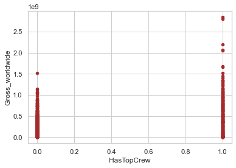

```python
corr = pearsonr(data2['HasTopCrew'], data2['Gross_worldwide'])[0]
print('Pearsons correlation between HasTopCrew and Gross: %.3f' % corr)
data2.plot.scatter(x='HasTopCrew', y='Gross_worldwide', color='brown')
```

```python
final['HasTopCrew'] = data2['HasTopCrew']
```

## Studio Analysis

Hypothesis: Is gross depends on number of Studios participate in?

```python
data2 = data.copy()
data2['NumStudios'] = data2['Studios'].apply(lambda x: len(x))
data2['NumStudios'].value_counts()
```

```
3    5307
2    2088
1    1291
0      41
4      22
5       3
Name: NumStudios, dtype: int64
```

```
Pearsons correlation between NumStudios and Gross: 0.133
```

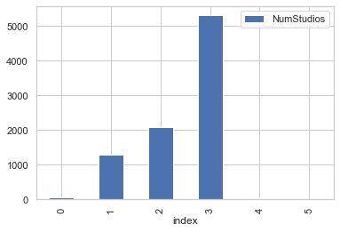

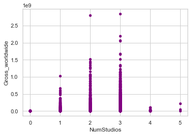

```python
data2['NumStudios'].value_counts().reset_index().sort_values(by='index', ascending=True).plot.bar(x='index',
                                                                                                  y='NumStudios')
corr = pearsonr(data2['NumStudios'], data2['Gross_worldwide'])[0]
print('Pearsons correlation between NumStudios and Gross: %.3f' % corr)
data2.plot.scatter(x='NumStudios', y='Gross_worldwide', color='purple')
```

```python
final['NumStudios'] = data2['NumStudios']
```

Movies with Number of Studios Of 4 or 5 may be outlier. We will try to drop it.

```python
data3 = data2.drop(list(data[data2['NumStudios'] == 4].index), axis=0)
data3 = data3.drop(list(data[data2['NumStudios'] == 5].index), axis=0)
```

```
Pearsons correlation between NumStudios and Gross: 0.135
```

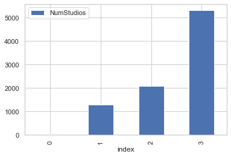

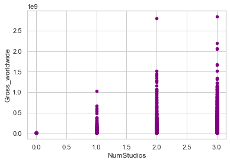

```python
data3['NumStudios'].value_counts().reset_index().sort_values(by='index', ascending=True).plot.bar(x='index',
                                                                                                  y='NumStudios')
corr = pearsonr(data3['NumStudios'], data3['Gross_worldwide'])[0]
print('Pearsons correlation between NumStudios and Gross: %.3f' % corr)
data3.plot.scatter(x='NumStudios', y='Gross_worldwide', color='purple')
```

Correlation stay the same so we don't need to delete them

Studio and Gross of the movies they work for

- Have not devide gross to each Studio if they coop together

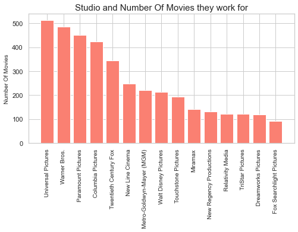

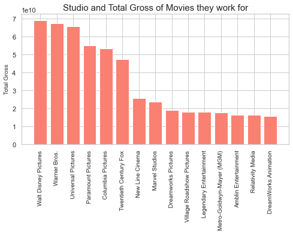

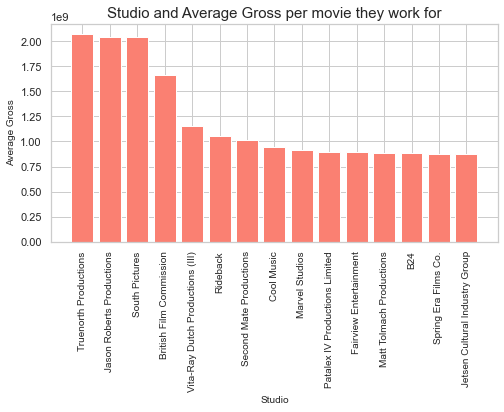

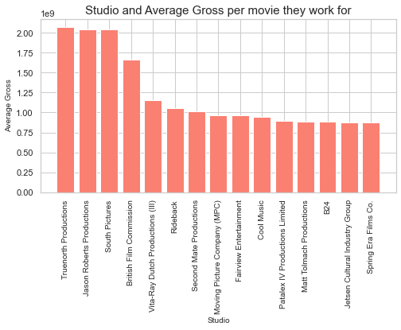

```python
studio = parseWithMoneyAndCount(data, 'Studios')
fig = plt.figure(figsize=(8, 4))
# plt.subplot(2,1,1)
data2 = studio.sort_values(by='Count', ascending=False)[0:15]
plt.bar(data=data2, x='Studios', height='Count', color="salmon")
plt.xticks(rotation=90, fontsize=10)
plt.ylabel("Number Of Movies", fontsize=10)
plt.title("Studio and Number Of Movies they work for", fontsize=15)
plt.show()

fig = plt.figure(figsize=(8, 4))
# plt.subplot(2,1,1)
data2 = studio.sort_values(by='Total', ascending=False)[0:15]
plt.bar(data=data2, x='Studios', height='Total', color="salmon")
plt.xticks(rotation=90, fontsize=10)
plt.ylabel("Total Gross", fontsize=10)
plt.title("Studio and Total Gross of Movies they work for", fontsize=15)
plt.show()
# plt.subplot(2,1,2)
fig = plt.figure(figsize=(8, 4))
data3 = studio.sort_values(by='Mean', ascending=False)[0:15]
plt.bar(data=data3, x='Studios', height='Mean', color="salmon")
plt.xticks(rotation=90, fontsize=10)
plt.title("Studio and Average Gross per movie they work for", fontsize=15)
plt.xlabel("Studio", fontsize=10)
plt.ylabel("Average Gross", fontsize=10)
plt.show()

fig = plt.figure(figsize=(8, 4))
data3 = studio.sort_values(by='Median', ascending=False)[0:15]
plt.bar(data=data3, x='Studios', height='Median', color="salmon")
plt.xticks(rotation=90, fontsize=10)
plt.title("Studio and Average Gross per movie they work for", fontsize=15)
plt.xlabel("Studio", fontsize=10)
plt.ylabel("Average Gross", fontsize=10)
plt.show()
```

```python
studio.sort_values(by='Mean', ascending=False)
```

|  | Studios | Total | Count | Mean | Median |
| --- | --- | --- | --- | --- | --- |
| 6417 | Truenorth Productions | 2069521700 | 1 | 2.069522e+09 | 2.069522e+09 |
| 3434 | Jason Roberts Productions | 2048359754 | 1 | 2.048360e+09 | 2.048360e+09 |
| 5820 | South Pictures | 2048359754 | 1 | 2.048360e+09 | 2.048360e+09 |
| 1021 | British Film Commission | 1662899439 | 1 | 1.662899e+09 | 1.662899e+09 |
| 6616 | Vita-Ray Dutch Productions (III) | 1153337496 | 1 | 1.153337e+09 | 1.153337e+09 |
| ... | ... | ... | ... | ... | ... |
| 4827 | Paramount Famous Lasky Corporation | 746 | 1 | 7.460000e+02 | 7.460000e+02 |
| 6659 | Walter Wanger Productions | 623 | 1 | 6.230000e+02 | 6.230000e+02 |
| 994 | Break Media | 528 | 1 | 5.280000e+02 | 5.280000e+02 |
| 1174 | Campfire | 528 | 1 | 5.280000e+02 | 5.280000e+02 |
| 3439 | Jaz Films | 95 | 1 | 9.500000e+01 | 9.500000e+01 |

6883 rows × 5 columns

This average gross plot for studio is not reliable to decide which Studio is big or not since there are some Studios which participate only in one Movie

We can define big studios by 4 ways:

- Number of movies releases
- Mean gross of movies they release
- Median gross of movies they release
- Total gross of movies they release

Now we will exclude the Studio with releases lower than 5

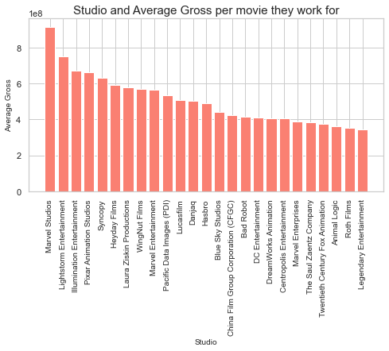

|  | Studios | Total | Count | Mean | Median |
| --- | --- | --- | --- | --- | --- |
| 4117 | Marvel Studios | 23795322645 | 26 | 9.152047e+08 | 813667029.0 |
| 3830 | Lightstorm Entertainment | 6754939278 | 9 | 7.505488e+08 | 378882411.0 |
| 3226 | Illumination Entertainment | 6693236668 | 10 | 6.693237e+08 | 588661184.5 |
| 4979 | Pixar Animation Studios | 14528032320 | 22 | 6.603651e+08 | 601716911.5 |
| 6029 | Syncopy | 3775191007 | 6 | 6.291985e+08 | 597530912.5 |
| ... | ... | ... | ... | ... | ... |
| 6843 | Zenith Entertainment | 17321794 | 8 | 2.165224e+06 | 1708545.5 |
| 4453 | National Film Board of Canada (NFB) | 14559833 | 7 | 2.079976e+06 | 1601612.0 |
| 4693 | Ontario Film Development Corporation | 8636461 | 6 | 1.439410e+06 | 1364006.0 |
| 3677 | La Sept Cinéma | 10915352 | 8 | 1.364419e+06 | 1229040.0 |
| 1593 | Concorde Pictures | 8463581 | 7 | 1.209083e+06 | 1242995.0 |

595 rows × 5 columns

```python
studios10Larger = studio[studio['Count'] > 5]
studios10Larger = studios10Larger.sort_values(by='Mean', ascending=False)
fig = plt.figure(figsize=(8, 4))
plt.bar(data=studios10Larger[0:25], x='Studios', height='Mean', color="salmon")
plt.xticks(rotation=90, fontsize=10)
plt.title("Studio and Average Gross per movie they work for", fontsize=15)
plt.xlabel("Studio", fontsize=10)
plt.ylabel("Average Gross", fontsize=10)
plt.show()
studios10Larger
```

The top studios bar chat now looks more familiar.

Move on to rank the Studios.

```python
studios10Larger.sort_values(by='Mean', ascending=True, inplace=True)
studioRank = dict()
for i, row in enumerate(studios10Larger['Studios']):
    studioRank[row] = i + 1
studioRank
```

```
{'Concorde Pictures': 1,
 'La Sept Cinéma': 2,
 'Ontario Film Development Corporation': 3,
 'National Film Board of Canada (NFB)': 4,
 'Zenith Entertainment': 5,
 'Duplass Brothers Productions': 6,
 'A&E IndieFilms': 7,
 'British Screen Productions': 8,
 'RAI Radiotelevisione Italiana': 9,
 'American Playhouse': 10,
 'Films A2': 11,
 'Sovereign Pictures': 12,
 'Lorimar Motion Pictures': 13,
 'Arte France Cinéma': 14,
 'Diamond Docs': 15,
 'MK2 Productions': 16,
 'Arts Council of England': 17,
 'Road Movies Filmproduktion': 18,
 'The Rank Organisation': 19,
 'October Films': 20,
 'Alliance Communications Corporation': 21,
 'Live Entertainment': 22,
 'Les Films Ariane': 23,
 'Trimark Pictures': 24,
 'Triumph Films': 25,
 'CBS Theatrical Films': 26,
 'Big Indie Pictures': 27,
 'Alliance Entertainment': 28,
 'Fine Line Features': 29,
 'Cineplex Odeon Films': 30,
 'Les Films Alain Sarde': 31,
 'Gener8Xion Entertainment': 32,
 'Téléfilm Canada': 33,
 'Rhombus Media': 34,
 'Canadian Film Development Corporation (CFDC)': 35,
 'CiBy 2000': 36,
 'Vision PDG': 37,
 'Lorimar Productions': 38,
 'Merchant Ivory Productions': 39,
 'Destination Films': 40,
```

[output cut: 540 more lines]

```
 'China Film Group Corporation (CFGC)': 581,
 'Blue Sky Studios': 582,
 'Hasbro': 583,
 'Danjaq': 584,
 'Lucasfilm': 585,
 'Pacific Data Images (PDI)': 586,
 'Marvel Entertainment': 587,
 'WingNut Films': 588,
 'Laura Ziskin Productions': 589,
 'Heyday Films': 590,
 'Syncopy': 591,
 'Pixar Animation Studios': 592,
 'Illumination Entertainment': 593,
 'Lightstorm Entertainment': 594,
 'Marvel Studios': 595}
```

Apply by get the max rank in the list of Studios for each movie

The studio not appear in the list will be randomly choose rank between **0** and **200**

```
Pearsons correlation between StudioRank and Gross: 0.392
```

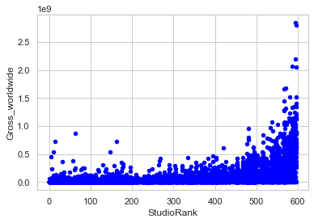

```python
import random


def getStudioRank(studios):
    max = 0
    for studio in studios:
        if studio not in studioRank.keys():
            continue
        if studioRank[studio] > max:
            max = studioRank[studio]
    if max != 0:
        return max
    return random.randint(1, 200)


data2 = data.copy()
data2['StudioRank'] = data2['Studios'].apply(getStudioRank)
corr = pearsonr(data2['StudioRank'], data2['Gross_worldwide'])[0]
print('Pearsons correlation between StudioRank and Gross: %.3f' % corr)
data2.plot.scatter(x='StudioRank', y='Gross_worldwide', color='blue')
```

Apply by get the total rank in the list of Studios for each movie

The studio not appear in the list will be randomly choose rank between **0** and **200**

```
Pearsons correlation between StudioRank and Gross: 0.473
```

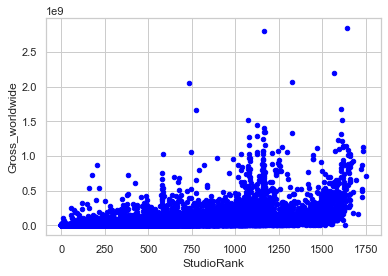

```python
import random


def getStudioRank(studios):
    total = 0
    for studio in studios:
        if studio not in studioRank.keys():
            total += random.randint(1, 200)
            continue
        total += studioRank[studio]
    return total


data2 = data.copy()
data2['StudioRank'] = data2['Studios'].apply(getStudioRank)
corr = pearsonr(data2['StudioRank'], data2['Gross_worldwide'])[0]
print('Pearsons correlation between StudioRank and Gross: %.3f' % corr)
data2.plot.scatter(x='StudioRank', y='Gross_worldwide', color='blue')
```

```python
final['StudioRank'] = data2['StudioRank']
```

Apply by get the mean rank in the list of Studios for each movie

The studio not appear in the list will be randomly choose rank between **0** and **200**

```
Pearsons correlation between StudioRank and Gross: 0.433
```

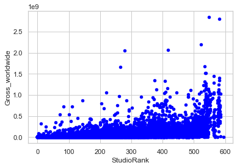

```python
import random


def getStudioRank(studios):
    total = 0
    length = len(studios)
    if length == 0:
        length = 1
    for studio in studios:
        if studio not in studioRank.keys():
            total += random.randint(0, 200)
            continue
        total += studioRank[studio]
    return total / length


data2 = data.copy()
data2['StudioRank'] = data2['Studios'].apply(getStudioRank)
corr = pearsonr(data2['StudioRank'], data2['Gross_worldwide'])[0]
print('Pearsons correlation between StudioRank and Gross: %.3f' % corr)
data2.plot.scatter(x='StudioRank', y='Gross_worldwide', color='blue')
```

Decide to choose **total rank**

Now we will extract more feature That is:

- Number of top studios(Studio that in the top **100**)
- Boolean (0,1) Have studio in high top (In top **30**)

NumTopStudios

```python
studios10Larger.sort_values(by='Mean', ascending=False, inplace=True)
top100Studios = list(studios10Larger['Studios'][0:100])


def getNumTopStudios(studios):
    total = 0
    for studio in studios:
        if studio in top100Studios:
            total += 1
    return total


data2 = data.copy()
data2['NumTopStudios'] = data2['Studios'].apply(getNumTopStudios)
data2['NumTopStudios'].value_counts()
```

```
0    7009
1    1248
2     433
3      62
Name: NumTopStudios, dtype: int64
```

```
Pearsons correlation between NumTopStudios and Gross: 0.530
```

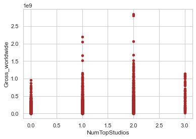

```python
corr = pearsonr(data2['NumTopStudios'], data2['Gross_worldwide'])[0]
print('Pearsons correlation between NumTopStudios and Gross: %.3f' % corr)
data2.plot.scatter(x='NumTopStudios', y='Gross_worldwide', color='brown')
```

```python
final['NumTopStudios'] = data2['NumTopStudios']
```

HasTopStudio

```
Pearsons correlation between HasTopStudio and Gross: 0.504
```

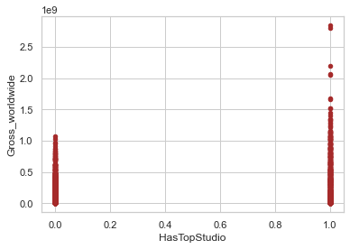

```python
studios10Larger.sort_values(by='Mean', ascending=False, inplace=True)
top100Studios = list(studios10Larger['Studios'][0:30])


def getHasTopStudio(studios):
    for studio in studios:
        if studio in top100Studios:
            return 1
    return 0


data2 = data.copy()
data2['HasTopStudio'] = data2['Studios'].apply(getHasTopStudio)
data2['HasTopStudio'].value_counts()
corr = pearsonr(data2['HasTopStudio'], data2['Gross_worldwide'])[0]
print('Pearsons correlation between HasTopStudio and Gross: %.3f' % corr)
data2.plot.scatter(x='HasTopStudio', y='Gross_worldwide', color='brown')
```

```python
final['HasTopStudio'] = data2['HasTopStudio']
```

## Production Countries Analysis

```python
data2 = data.copy()
data2['Countries'] = data2['Countries'].apply(lambda x: len(x))
data2['Countries'].value_counts()
```

```
1     5743
2     1873
3      676
4      269
5      114
6       45
7       10
8       10
0        5
9        4
11       2
19       1
Name: Countries, dtype: int64
```

```
Pearsons correlation between Countries and Gross: 0.087
```

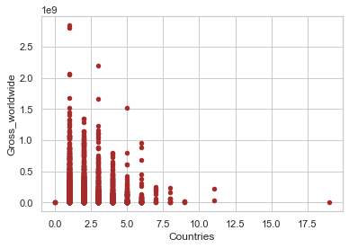

```python
corr = pearsonr(data2['Countries'], data2['Gross_worldwide'])[0]
print('Pearsons correlation between Countries and Gross: %.3f' % corr)
data2.plot.scatter(x='Countries', y='Gross_worldwide', color='brown')
```

Gross of each countries and Total Gross

- Have not devide gross to each Country if they coop together

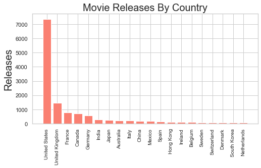

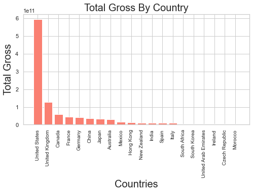

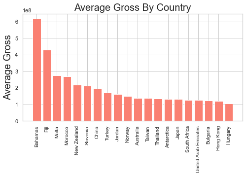

```python
country = parseWithMoneyAndCount(data, 'Countries')
# country=country[country['Count']>20]
fig = plt.figure(figsize=(8, 4))
# plt.subplot(2,1,1)
data2 = country.sort_values(by='Count', ascending=False)[0:20]
plt.bar(data=data2, x='Countries', height='Count', color="salmon")
plt.xticks(rotation=90, fontsize=10)
plt.ylabel("Releases", fontsize=20)
plt.title("Movie Releases By Country", fontsize=20)
fig = plt.figure(figsize=(8, 4))
# plt.subplot(2,1,2)
data2 = country.sort_values(by='Total', ascending=False)[0:20]
plt.bar(data=data2, x='Countries', height='Total', color="salmon")
plt.ylabel("Total Gross", fontsize=20)
plt.xticks(rotation=90, fontsize=10)
plt.xlabel("Countries", fontsize=20)
plt.title("Total Gross By Country", fontsize=20)

fig = plt.figure(figsize=(8, 4))
# plt.subplot(2,1,1)
data2 = country.sort_values(by='Mean', ascending=False)[0:20]
plt.bar(data=data2, x='Countries', height='Mean', color="salmon")
plt.xticks(rotation=90, fontsize=10)
plt.ylabel("Average Gross", fontsize=20)
plt.title("Average Gross By Country", fontsize=20)
plt.show()
## This use for QUESTION 8
list_country = list(country['Countries'])
```

This rank of average gross is not relevant since there are some countries with only least release count

```python
country.sort_values(by='Mean', ascending=False)
```

|  | Countries | Total | Count | Mean | Median |
| --- | --- | --- | --- | --- | --- |
| 6 | Bahamas | 616502912 | 1 | 6.165029e+08 | 616502912.0 |
| 32 | Fiji | 429632142 | 1 | 4.296321e+08 | 429632142.0 |
| 62 | Malta | 3027543520 | 11 | 2.752312e+08 | 240697856.0 |
| 67 | Morocco | 3758242989 | 14 | 2.684459e+08 | 151314187.0 |
| 72 | New Zealand | 10467742795 | 48 | 2.180780e+08 | 74271180.0 |
| ... | ... | ... | ... | ... | ... |
| 10 | Bhutan | 1792370 | 2 | 8.961850e+05 | 896185.0 |
| 93 | Soviet Union | 2311743 | 3 | 7.705810e+05 | 93292.0 |
| 35 | Georgia | 686704 | 1 | 6.867040e+05 | 686704.0 |
| 58 | Liberia | 555533 | 1 | 5.555330e+05 | 555533.0 |
| 39 | Haiti | 352296 | 1 | 3.522960e+05 | 352296.0 |

111 rows × 5 columns

We can see that almost movies are release in United States.

We will test that: Is movies release in United States will have higher gross compare to other films?

```
Pearsons correlation between isUnitedStates and Gross: 0.129
```

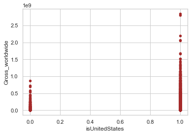

```python
data2 = data.copy()
data2['isUnitedStates'] = data2['Countries'].apply(lambda x: 1 if "United States" in x else 0)
corr = pearsonr(data2['isUnitedStates'], data2['Gross_worldwide'])[0]
print('Pearsons correlation between isUnitedStates and Gross: %.3f' % corr)
data2.plot.scatter(x='isUnitedStates', y='Gross_worldwide', color='brown')
```

```python
final['isUnitedStates'] = data2['isUnitedStates']
```

Seems low correlation

Now we will exclude countries that have number of releases less than 100

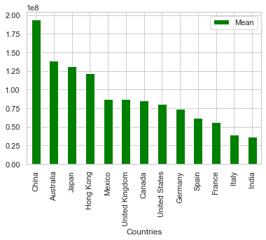

```python
country.sort_values(by='Mean', ascending=False)
release100Countries = country[country['Count'] >= 100]
release100Countries = release100Countries.sort_values(by='Mean', ascending=False)
release100Countries.plot.bar(x='Countries', y='Mean', color='green')
```

We will choose these list of Countries to extract a rank feature

```python
release100Countries = release100Countries.sort_values(by='Mean', ascending=True).reset_index(drop=True)
countryRank = dict()
for i, row in enumerate(release100Countries['Countries']):
    countryRank[row] = i + 1  ## Plus 1 in order to release the 0 position for another film
countryRank
```

```
{'India': 1,
 'Italy': 2,
 'France': 3,
 'Spain': 4,
 'Germany': 5,
 'United States': 6,
 'Canada': 7,
 'United Kingdom': 8,
 'Mexico': 9,
 'Hong Kong': 10,
 'Japan': 11,
 'Australia': 12,
 'China': 13}
```

Get rank by the maximum

```
Pearsons correlation between CountryRank and Gross: 0.153
```

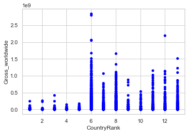

```python
def getCountryRank(countries):
    max = 0
    for country in countries:
        if country not in countryRank.keys():
            continue
        if countryRank[country] > max:
            max = countryRank[country]
    if max == 0:
        max = random.randint(1, 10)
    return max


data2 = data.copy()
data2['CountryRank'] = data2['Countries'].apply(getCountryRank)
corr = pearsonr(data2['CountryRank'], data2['Gross_worldwide'])[0]
print('Pearsons correlation between CountryRank and Gross: %.3f' % corr)
data2.plot.scatter(x='CountryRank', y='Gross_worldwide', color='blue')
```

```python
final['CountryRank'] = data2['CountryRank']
```

By total

```
Pearsons correlation between CountryRank and Gross: 0.161
```

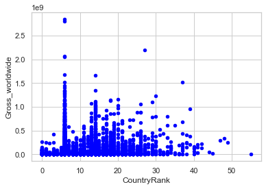

```python
def getCountryRank(countries):
    total = 0
    for country in countries:
        if country not in countryRank.keys():
            continue
        total += countryRank[country]
    return total


data2 = data.copy()
data2['CountryRank'] = data2['Countries'].apply(getCountryRank)
corr = pearsonr(data2['CountryRank'], data2['Gross_worldwide'])[0]
print('Pearsons correlation between CountryRank and Gross: %.3f' % corr)
data2.plot.scatter(x='CountryRank', y='Gross_worldwide', color='blue')
```

By in the list

```
Pearsons correlation between CountryRank and Gross: 0.034
```

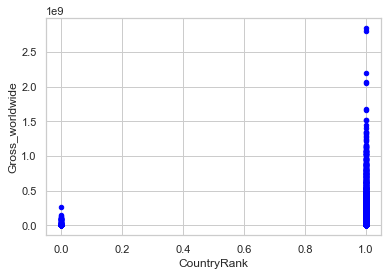

```python
def getCountryRank(countries):
    for country in countries:
        if country not in countryRank.keys():
            continue
        return 1
    return 0


data2 = data.copy()
data2['CountryRank'] = data2['Countries'].apply(getCountryRank)
corr = pearsonr(data2['CountryRank'], data2['Gross_worldwide'])[0]
print('Pearsons correlation between CountryRank and Gross: %.3f' % corr)
data2.plot.scatter(x='CountryRank', y='Gross_worldwide', color='blue')
```

## Language analysis

How distribution release by Languague

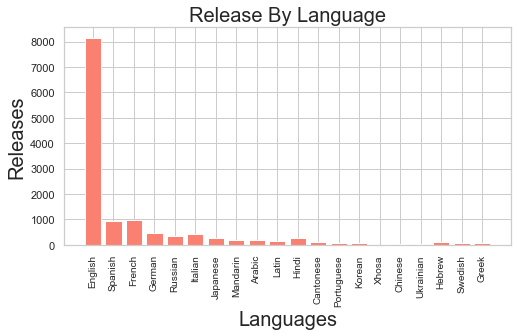

```python
language = parseWithMoneyAndCount(data, 'Languages')
data2 = language.sort_values(by='Total', ascending=False)[0:20]

fig = plt.figure(figsize=(8, 4))
plt.bar(data=data2, x='Languages', height='Count', color="salmon")
plt.ylabel("Releases", fontsize=20)
plt.xticks(rotation=90, fontsize=10)
plt.xlabel("Languages", fontsize=20)
plt.title("Release By Language", fontsize=20)
plt.show()
```

Nowadays, films almost have English. We will try to find that what is the film is spoken in English or another languages

```python
data2 = data.copy()
data2['IsEnglish'] = data2['Languages'].apply(lambda x: 1 if 'English' in x else 0)
data2['IsEnglish'].value_counts()
```

```
1    8150
0     602
Name: IsEnglish, dtype: int64
```

```
Pearsons correlation between IsEnnglish and Gross: 0.076
```

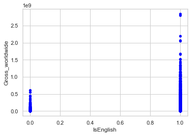

```python
corr = pearsonr(data2['IsEnglish'], data2['Gross_worldwide'])[0]
print('Pearsons correlation between IsEnnglish and Gross: %.3f' % corr)
data2.plot.scatter(x='IsEnglish', y='Gross_worldwide', color='blue')
```

Correlation of 0.076

```python
final['IsEnglish'] = data2['IsEnglish']
```

## Keywords analysis

Hypothesis: Is gross depend on number of keywords?

```python
data2 = data.copy()
data2['NumKeywords'] = data2['Keywords'].apply(lambda x: len(x))
data2['NumKeywords'].value_counts()
```

```
5    8566
1      89
2      34
4      24
3      21
0      18
Name: NumKeywords, dtype: int64
```

```
Pearsons correlation between NumKeywords and Gross: 0.043
```

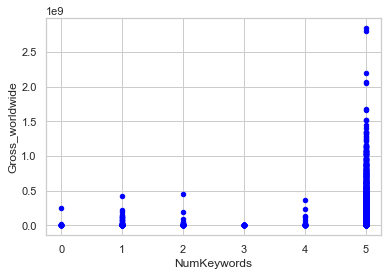

```python
corr = pearsonr(data2['NumKeywords'], data2['Gross_worldwide'])[0]
print('Pearsons correlation between NumKeywords and Gross: %.3f' % corr)
data2.plot.scatter(x='NumKeywords', y='Gross_worldwide', color='blue')
```

Not relevant

How distribution of gross by Keywords

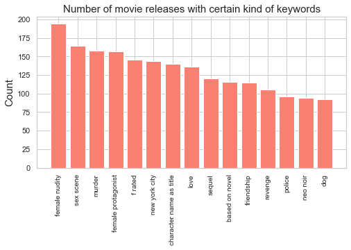

```python
keyword = parseWithMoneyAndCount(data, 'Keywords')
fig = plt.figure(figsize=(8, 4))
data2 = keyword.sort_values(by='Count', ascending=False)[0:15]
plt.bar(data=data2, x='Keywords', height='Count', color="salmon")
plt.xticks(rotation=90, fontsize=10)
plt.title("Number of movie releases with certain kind of keywords", fontsize=15)
plt.ylabel("Count", fontsize=15)
```

```python
keyword.sort_values(by='Mean', ascending=False)[0:10]
```

|  | Keywords | Total | Count | Mean | Median |
| --- | --- | --- | --- | --- | --- |
| 4833 | forest protection | 2847246203 | 1 | 2.847246e+09 | 2.847246e+09 |
| 2911 | cosmic | 2797501328 | 1 | 2.797501e+09 | 2.797501e+09 |
| 7144 | love affair | 2201647264 | 1 | 2.201647e+09 | 2.201647e+09 |
| 10605 | sailor's death | 2201647264 | 1 | 2.201647e+09 | 2.201647e+09 |
| 11980 | sunken ship | 2201647264 | 1 | 2.201647e+09 | 2.201647e+09 |
| 10649 | sanitation employee | 2069521700 | 1 | 2.069522e+09 | 2.069522e+09 |
| 3314 | death of recurring character | 2048359754 | 1 | 2.048360e+09 | 2.048360e+09 |
| 10574 | s.h.i.e.l.d. | 1518815515 | 1 | 1.518816e+09 | 1.518816e+09 |
| 2063 | car falling off a cliff | 1515341399 | 1 | 1.515341e+09 | 1.515341e+09 |
| 3521 | disney animated sequel | 1450026933 | 1 | 1.450027e+09 | 1.450027e+09 |

```python
keyword.sort_values(by='Median', ascending=False)[0:10]
```

|  | Keywords | Total | Count | Mean | Median |
| --- | --- | --- | --- | --- | --- |
| 4833 | forest protection | 2847246203 | 1 | 2.847246e+09 | 2.847246e+09 |
| 2911 | cosmic | 2797501328 | 1 | 2.797501e+09 | 2.797501e+09 |
| 7144 | love affair | 2201647264 | 1 | 2.201647e+09 | 2.201647e+09 |
| 11980 | sunken ship | 2201647264 | 1 | 2.201647e+09 | 2.201647e+09 |
| 10605 | sailor's death | 2201647264 | 1 | 2.201647e+09 | 2.201647e+09 |
| 10649 | sanitation employee | 2069521700 | 1 | 2.069522e+09 | 2.069522e+09 |
| 3314 | death of recurring character | 2048359754 | 1 | 2.048360e+09 | 2.048360e+09 |
| 10574 | s.h.i.e.l.d. | 1518815515 | 1 | 1.518816e+09 | 1.518816e+09 |
| 2063 | car falling off a cliff | 1515341399 | 1 | 1.515341e+09 | 1.515341e+09 |
| 3521 | disney animated sequel | 1450026933 | 1 | 1.450027e+09 | 1.450027e+09 |

These keywords have high mean and median except the truth that have only 1 count

```python
count50Keywords = keyword[keyword['Count'] > 20]
count50Keywords.sort_values(by='Mean', ascending=False)
```

|  | Keywords | Total | Count | Mean | Median |
| --- | --- | --- | --- | --- | --- |
| 11995 | superhero | 32041168607 | 61 | 5.252651e+08 | 370569774.0 |
| 1120 | based on comic book | 10474265400 | 25 | 4.189706e+08 | 230884728.0 |
| 7217 | magic | 10738490415 | 36 | 2.982914e+08 | 111927462.0 |
| 9413 | princess | 6618049857 | 25 | 2.647220e+08 | 55534455.0 |
| 6675 | king | 7831973626 | 30 | 2.610658e+08 | 57671894.0 |
| ... | ... | ... | ... | ... | ... |
| 8615 | one word title | 1203447244 | 68 | 1.769775e+07 | 6258238.5 |
| 12603 | topless female nudity | 609853613 | 37 | 1.648253e+07 | 3039587.0 |
| 7275 | male full frontal nudity | 434996581 | 30 | 1.449989e+07 | 3005289.5 |
| 5839 | homosexual | 361636313 | 35 | 1.033247e+07 | 5526675.0 |
| 6154 | independent film | 166134909 | 33 | 5.034391e+06 | 1467396.0 |

306 rows × 5 columns

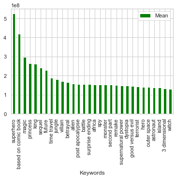

```python
count50Keywords.sort_values(by='Mean', ascending=False)[0:30].plot.bar(x='Keywords', y='Mean', color='green')
```

**superhero** keywords is popular in the 2010s and have high average gross

Rank keywords

```python
count50Keywords = count50Keywords.sort_values(by='Mean', ascending=True).reset_index(drop=True)
keywordRank = dict()
for i, row in enumerate(count50Keywords['Keywords']):
    keywordRank[row] = i + 1  ## Plus 1 in order to release the 0 position for another film
keywordRank
```

```
{'independent film': 1,
 'homosexual': 2,
 'male full frontal nudity': 3,
 'topless female nudity': 4,
 'one word title': 5,
 'scene during opening credits': 6,
 'timeframe 1990s': 7,
 'lust': 8,
 'title directed by female': 9,
 'female frontal nudity': 10,
 'three word title': 11,
 'infidelity': 12,
 'written by director': 13,
 'male frontal nudity': 14,
 'student': 15,
 'african american': 16,
 'bare breasts': 17,
 'lesbian': 18,
 'hood': 19,
 'bar': 20,
 'actor': 21,
 'breasts': 22,
 'two word title': 23,
 'vietnam war veteran': 24,
 'restaurant': 25,
 'secret': 26,
 'gay': 27,
 'watching tv': 28,
 'coming of age': 29,
 'slasher': 30,
 'obsession': 31,
 'widow': 32,
 '1950s': 33,
 'period drama': 34,
 'public nudity': 35,
 'panties': 36,
 'satire': 37,
 'woman on top': 38,
 'jewish': 39,
 'male rear nudity': 40,
```

[output cut: 251 more lines]

```
 'surprise ending': 292,
 'battle': 293,
 'post apocalypse': 294,
 'alien': 295,
 'betrayal': 296,
 'villain': 297,
 'jungle': 298,
 'time travel': 299,
 'future': 300,
 'sequel': 301,
 'king': 302,
 'princess': 303,
 'magic': 304,
 'based on comic book': 305,
 'superhero': 306}
```

Get rank for keywords by maximum

```
Pearsons correlation between keywordRank and Gross: 0.167
```

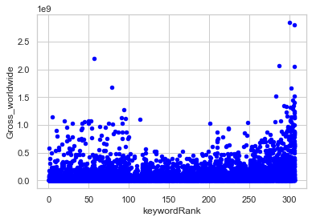

```python
import random


def getKeywordsRank(keywords):
    max = 0
    for keyword in keywords:
        if keyword not in keywordRank.keys():
            continue
        if keywordRank[keyword] > max:
            max = keywordRank[keyword]
    if max == 0:
        max = random.randint(1, 100)
    return max


data2 = data.copy()
data2['keywordRank'] = data2['Keywords'].apply(getKeywordsRank)
corr = pearsonr(data2['keywordRank'], data2['Gross_worldwide'])[0]
print('Pearsons correlation between keywordRank and Gross: %.3f' % corr)
data2.plot.scatter(x='keywordRank', y='Gross_worldwide', color='blue')
```

```
Pearsons correlation between keywordRank and Gross: 0.162
```

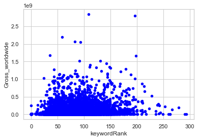

```python
import random


def getKeywordsRank(keywords):
    total = 0
    length = len(keywords)
    if length == 0:
        length = 1
    for keyword in keywords:
        if keyword not in keywordRank.keys():
            total += random.randint(1, 100)
            continue
        total += keywordRank[keyword]
    return total / length


data2 = data.copy()
data2['keywordRank'] = data2['Keywords'].apply(getKeywordsRank)
corr = pearsonr(data2['keywordRank'], data2['Gross_worldwide'])[0]
print('Pearsons correlation between keywordRank and Gross: %.3f' % corr)
data2.plot.scatter(x='keywordRank', y='Gross_worldwide', color='blue')
```

```python
final['keywordRank'] = data2['keywordRank']
```

## MPAA Analysis

How distribution of gross by MPAA Certificate

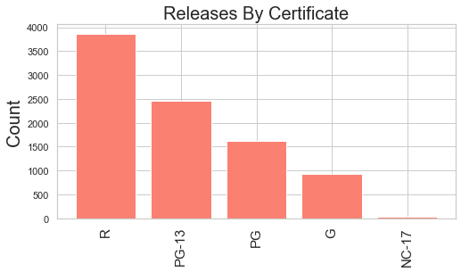

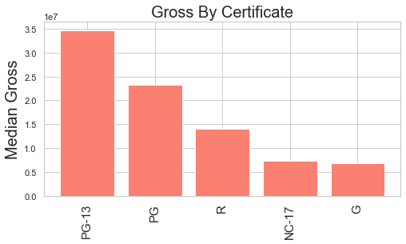

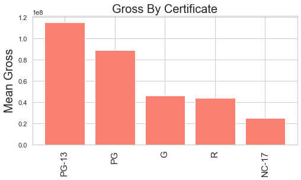

```python
certificate = parseWithMoneyAndCount(data, 'ListOfCertificate')
fig = plt.figure(figsize=(8, 4))
data2 = certificate.sort_values(by='Count', ascending=False)
plt.bar(data=data2, x='ListOfCertificate', height='Count', color="salmon")
plt.xticks(rotation=90, fontsize=15)
plt.ylabel("Count", fontsize=20)
plt.title("Releases By Certificate", fontsize=20)
plt.show()
fig = plt.figure(figsize=(8, 4))
data2 = certificate.sort_values(by='Median', ascending=False)
plt.bar(data=data2, x='ListOfCertificate', height='Median', color="salmon")
plt.xticks(rotation=90, fontsize=15)
plt.ylabel("Median Gross", fontsize=20)
plt.title("Gross By Certificate", fontsize=20)
plt.show()
fig = plt.figure(figsize=(8, 4))
data2 = certificate.sort_values(by='Mean', ascending=False)
plt.bar(data=data2, x='ListOfCertificate', height='Mean', color="salmon")
plt.xticks(rotation=90, fontsize=15)
plt.ylabel("Mean Gross", fontsize=20)
plt.title("Gross By Certificate", fontsize=20)
plt.show()
```

NC-17 has the least numbers of release

```python
certificate
```

|  | ListOfCertificate | Total | Count | Mean | Median |
| --- | --- | --- | --- | --- | --- |
| 0 | G | 42824185750 | 937 | 4.570351e+07 | 6780490.0 |
| 1 | NC-17 | 925845011 | 37 | 2.502284e+07 | 7412216.0 |
| 2 | PG | 144055409565 | 1621 | 8.886824e+07 | 23237911.0 |
| 3 | PG-13 | 283553468080 | 2466 | 1.149852e+08 | 34714400.0 |
| 4 | R | 170006305715 | 3867 | 4.396336e+07 | 14000000.0 |

Conduct rank by Certificate

By Mean

```python
certificate = certificate.sort_values(by='Mean', ascending=True).reset_index(drop=True)
cerRank = dict()
for i, row in enumerate(certificate['ListOfCertificate']):
    cerRank[row] = i + 1
cerRank
```

```
{'NC-17': 1, 'R': 2, 'G': 3, 'PG': 4, 'PG-13': 5}
```

```
Pearsons correlation between cerRank and Gross: 0.199
```

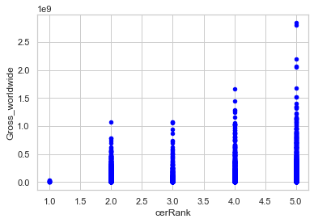

```python
def getCerRank(cers):
    max = 0
    for cer in cers:
        if cer not in cerRank.keys():
            continue
        if cerRank[cer] > max:
            max = cerRank[cer]
    return max


data2 = data.copy()
data2['cerRank'] = data2['ListOfCertificate'].apply(getCerRank)
corr = pearsonr(data2['cerRank'], data2['Gross_worldwide'])[0]
print('Pearsons correlation between cerRank and Gross: %.3f' % corr)
data2.plot.scatter(x='cerRank', y='Gross_worldwide', color='blue')
```

```python
final['cerRank'] = data2['cerRank']
```

See that PG-13 have the highest mean gross.

We will test that is movie have rated PG-13 will have more gross than others.

```
Pearsons correlation between PG-13 and Gross: 0.173
```

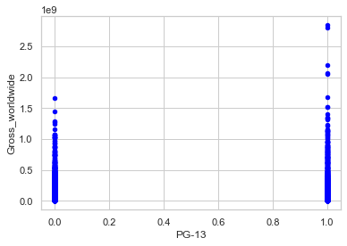

```python
data2 = data.copy()
data2['PG-13'] = data2['ListOfCertificate'].apply(lambda x: 1 if 'PG-13' in x else 0)
corr = pearsonr(data2['PG-13'], data2['Gross_worldwide'])[0]
print('Pearsons correlation between PG-13 and Gross: %.3f' % corr)
data2.plot.scatter(x='PG-13', y='Gross_worldwide', color='blue')
```

## Export to CSV

```python
final.to_csv('../dataset/extracted/feature_extracted.csv', index=False)
```